# NCAA

## Introduction

# Although I am not a huge college basketball fan, I find this particular data set fascinating in its richness. Let’s dig in and see what we can learn about the history of March Madness. Hopefully along the way, I’ll discover something useful to use in your models.

## Libraries

```r
library(data.table)
library(dplyr)
library(magrittr)
```

```r
library(ggplot2)
library(gridExtra)
library(ggExtra)
theme_set(theme_bw())
```

```r
# Data Section 1
teams <- fread('./DataFiles/Teams.csv')
seasons <- fread('./DataFiles/Seasons.csv')
seeds <- fread('./DataFiles/NCAATourneySeeds.csv')
seas_results <- fread('./DataFiles/RegularSeasonCompactResults.csv')
tour_results <- fread('./DataFiles/NCAATourneyCompactResults.csv')
seas_detail <- fread('./DataFiles/RegularSeasonDetailedResults.csv')
tour_detail <- fread('./DataFiles/NCAATourneyDetailedResults.csv')
conferences <- fread('./DataFiles/Conferences.csv')
team_conferences <- fread('./DataFiles/TeamConferences.csv')
coaches <- fread('./DataFiles/TeamCoaches.csv')
```

## Data Overview

```r
glimpse(teams)
```

```
## Observations: 364
## Variables: 4
## $ TeamID        <int> 1101, 1102, 1103, 1104, 1105, 1106, 1107, 1108, ...
## $ TeamName      <chr> "Abilene Chr", "Air Force", "Akron", "Alabama", ...
## $ FirstD1Season <int> 2014, 1985, 1985, 1985, 2000, 1985, 2000, 1985, ...
## $ LastD1Season  <int> 2018, 2018, 2018, 2018, 2018, 2018, 2018, 2018, ...
```

```r
glimpse(seasons)
```

```
## Observations: 34
## Variables: 6
## $ Season  <int> 1985, 1986, 1987, 1988, 1989, 1990, 1991, 1992, 1993, ...
## $ DayZero <chr> "10/29/1984", "10/28/1985", "10/27/1986", "11/2/1987",...
## $ RegionW <chr> "East", "East", "East", "East", "East", "East", "East"...
## $ RegionX <chr> "West", "Midwest", "Southeast", "Midwest", "West", "Mi...
## $ RegionY <chr> "Midwest", "Southeast", "Midwest", "Southeast", "Midwe...
## $ RegionZ <chr> "Southeast", "West", "West", "West", "Southeast", "Wes...
```

```r
glimpse(seeds)
```

```
## Observations: 2,150
## Variables: 3
## $ Season <int> 1985, 1985, 1985, 1985, 1985, 1985, 1985, 1985, 1985, 1...
## $ Seed   <chr> "W01", "W02", "W03", "W04", "W05", "W06", "W07", "W08",...
## $ TeamID <int> 1207, 1210, 1228, 1260, 1374, 1208, 1393, 1396, 1439, 1...
```

```r
glimpse(seas_results)
```

```
## Observations: 150,684
## Variables: 8
## $ Season  <int> 1985, 1985, 1985, 1985, 1985, 1985, 1985, 1985, 1985, ...
## $ DayNum  <int> 20, 25, 25, 25, 25, 25, 25, 25, 25, 25, 25, 25, 25, 25...
## $ WTeamID <int> 1228, 1106, 1112, 1165, 1192, 1218, 1228, 1242, 1260, ...
## $ WScore  <int> 81, 77, 63, 70, 86, 79, 64, 58, 98, 97, 103, 75, 91, 7...
## $ LTeamID <int> 1328, 1354, 1223, 1432, 1447, 1337, 1226, 1268, 1133, ...
## $ LScore  <int> 64, 70, 56, 54, 74, 78, 44, 56, 80, 89, 71, 71, 72, 65...
## $ WLoc    <chr> "N", "H", "H", "H", "H", "H", "N", "N", "H", "H", "H",...
## $ NumOT   <int> 0, 0, 0, 0, 0, 0, 0, 0, 0, 0, 0, 0, 0, 0, 0, 0, 0, 0, ...
```

```r
glimpse(tour_results)
```

```
## Observations: 2,117
## Variables: 8
## $ Season  <int> 1985, 1985, 1985, 1985, 1985, 1985, 1985, 1985, 1985, ...
## $ DayNum  <int> 136, 136, 136, 136, 136, 136, 136, 136, 136, 136, 136,...
## $ WTeamID <int> 1116, 1120, 1207, 1229, 1242, 1246, 1256, 1260, 1314, ...
## $ WScore  <int> 63, 59, 68, 58, 49, 66, 78, 59, 76, 79, 75, 96, 85, 83...
## $ LTeamID <int> 1234, 1345, 1250, 1425, 1325, 1449, 1338, 1233, 1292, ...
## $ LScore  <int> 54, 58, 43, 55, 38, 58, 54, 58, 57, 70, 64, 83, 68, 59...
## $ WLoc    <chr> "N", "N", "N", "N", "N", "N", "N", "N", "N", "N", "N",...
## $ NumOT   <int> 0, 0, 0, 0, 0, 0, 0, 0, 0, 0, 0, 0, 0, 0, 0, 0, 0, 0, ...
```

```r
glimpse(seas_detail)
```

```
## Observations: 76,636
## Variables: 34
## $ Season  <int> 2003, 2003, 2003, 2003, 2003, 2003, 2003, 2003, 2003, ...
## $ DayNum  <int> 10, 10, 11, 11, 11, 11, 12, 12, 12, 12, 13, 13, 13, 13...
## $ WTeamID <int> 1104, 1272, 1266, 1296, 1400, 1458, 1161, 1186, 1194, ...
## $ WScore  <int> 68, 70, 73, 56, 77, 81, 80, 75, 71, 84, 106, 74, 66, 7...
## $ LTeamID <int> 1328, 1393, 1437, 1457, 1208, 1186, 1236, 1457, 1156, ...
## $ LScore  <int> 62, 63, 61, 50, 71, 55, 62, 61, 66, 56, 50, 73, 65, 48...
## $ WLoc    <chr> "N", "N", "N", "N", "N", "H", "H", "N", "N", "H", "H",...
## $ NumOT   <int> 0, 0, 0, 0, 0, 0, 0, 0, 0, 0, 0, 0, 0, 0, 1, 0, 0, 0, ...
## $ WFGM    <int> 27, 26, 24, 18, 30, 26, 23, 28, 28, 32, 41, 29, 26, 25...
## $ WFGA    <int> 58, 62, 58, 38, 61, 57, 55, 62, 58, 67, 69, 51, 66, 56...
## $ WFGM3   <int> 3, 8, 8, 3, 6, 6, 2, 4, 5, 5, 15, 7, 5, 10, 11, 10, 5,...
## $ WFGA3   <int> 14, 20, 18, 9, 14, 12, 8, 14, 11, 17, 25, 13, 19, 23, ...
## $ WFTM    <int> 11, 10, 17, 17, 11, 23, 32, 15, 10, 15, 9, 9, 9, 16, 1...
```

[output cut: 21 more lines]

```r
glimpse(tour_detail)
```

```
## Observations: 981
## Variables: 34
## $ Season  <int> 2003, 2003, 2003, 2003, 2003, 2003, 2003, 2003, 2003, ...
## $ DayNum  <int> 134, 136, 136, 136, 136, 136, 136, 136, 136, 136, 136,...
## $ WTeamID <int> 1421, 1112, 1113, 1141, 1143, 1163, 1181, 1211, 1228, ...
## $ WScore  <int> 92, 80, 84, 79, 76, 58, 67, 74, 65, 64, 72, 72, 70, 71...
## $ LTeamID <int> 1411, 1436, 1272, 1166, 1301, 1140, 1161, 1153, 1443, ...
## $ LScore  <int> 84, 51, 71, 73, 74, 53, 57, 69, 60, 61, 68, 71, 69, 54...
## $ WLoc    <chr> "N", "N", "N", "N", "N", "N", "N", "N", "N", "N", "N",...
## $ NumOT   <int> 1, 0, 0, 0, 1, 0, 0, 0, 0, 0, 0, 0, 0, 0, 0, 0, 0, 1, ...
## $ WFGM    <int> 32, 31, 31, 29, 27, 17, 19, 20, 24, 28, 22, 28, 23, 24...
## $ WFGA    <int> 69, 66, 59, 53, 64, 52, 54, 47, 56, 51, 51, 52, 54, 52...
## $ WFGM3   <int> 11, 7, 6, 3, 7, 4, 4, 6, 5, 2, 9, 5, 3, 10, 8, 8, 6, 7...
## $ WFGA3   <int> 29, 23, 14, 7, 20, 14, 13, 14, 14, 6, 16, 13, 13, 18, ...
## $ WFTM    <int> 17, 11, 16, 18, 15, 20, 25, 28, 12, 6, 19, 11, 21, 13,...
```

[output cut: 21 more lines]

```r
glimpse(conferences)
```

```
## Observations: 51
## Variables: 2
## $ ConfAbbrev  <chr> "a_sun", "a_ten", "aac", "acc", "aec", "asc", "awc...
## $ Description <chr> "Atlantic Sun Conference", "Atlantic 10 Conference...
```

```r
glimpse(team_conferences)
```

```
## Observations: 10,888
## Variables: 3
## $ Season     <int> 1985, 1985, 1985, 1985, 1985, 1985, 1985, 1985, 198...
## $ TeamID     <int> 1114, 1147, 1204, 1209, 1215, 1223, 1273, 1359, 118...
## $ ConfAbbrev <chr> "a_sun", "a_sun", "a_sun", "a_sun", "a_sun", "a_sun...
```

```r
glimpse(coaches)
```

```
## Observations: 10,992
## Variables: 5
## $ Season      <int> 1985, 1985, 1985, 1985, 1985, 1985, 1985, 1985, 19...
## $ TeamID      <int> 1102, 1103, 1104, 1106, 1108, 1109, 1110, 1111, 11...
## $ FirstDayNum <int> 0, 0, 0, 0, 0, 0, 0, 0, 0, 0, 0, 0, 0, 0, 0, 0, 0,...
## $ LastDayNum  <int> 154, 154, 154, 154, 154, 154, 154, 154, 154, 154, ...
## $ CoachName   <chr> "reggie_minton", "bob_huggins", "wimp_sanderson", ...
```

## Historical Performance

### Teams

# What have been the most successful teams since 1985? We’ll attempt to determine this with the metrics: regular season wins, number 1 seeds, tournament wins, and championships.

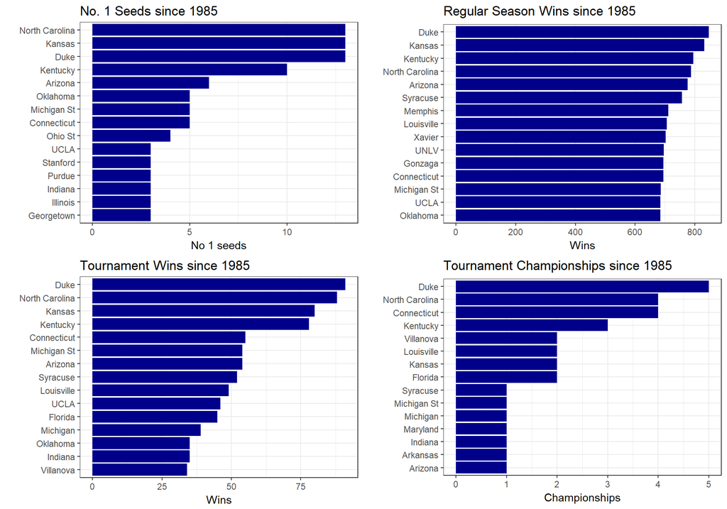

```r
setkey(teams, TeamID)
setkey(seeds, TeamID)

g1 <-
teams[seeds][, one_seed := as.numeric(substr(Seed, 2, 3)) == 1][, sum(one_seed), by = TeamName][order(V1, decreasing = T)][1:15,] %>%
ggplot(aes(x = reorder(TeamName, V1), y = V1)) +
geom_bar(stat = 'identity', fill = 'darkblue') +
labs(x = '', y = 'No 1 seeds', title = 'No. 1 Seeds since 1985') +
coord_flip()

setkey(seas_results, WTeamID)

g2 <-
seas_results[teams][, .(wins = .N), by = TeamName][order(-wins)][1:15,] %>%
ggplot(aes(x = reorder(TeamName, wins), y = wins)) +
geom_bar(stat = 'identity', fill = 'darkblue') +
labs(x = '', y = 'Wins', title = 'Regular Season Wins since 1985') +
coord_flip()

setkey(tour_results, WTeamID)

g3 <-
tour_results[teams][, .(wins = .N), by = TeamName][order(-wins)][1:15,] %>%
ggplot(aes(x = reorder(TeamName, wins), y = wins)) +
geom_bar(stat = 'identity', fill = 'darkblue') +
labs(x = '', y = 'Wins', title = 'Tournament Wins since 1985') +
coord_flip()

g4 <-
tour_results[teams][DayNum == 154, .(wins = .N), by = TeamName][order(-wins)][1:15,] %>%
ggplot(aes(x = reorder(TeamName, wins), y = wins)) +
geom_bar(stat = 'identity', fill = 'darkblue') +
labs(x = '', y = 'Championships', title = 'Tournament Championships since 1985') +
coord_flip()

grid.arrange(g1, g2, g3, g4, nrow = 2)
```

### Conferences

# What about conferences? Which conferences have produced the most championships since 1985?

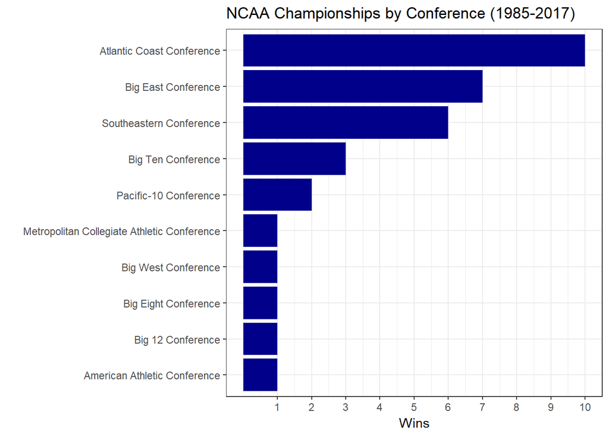

```r
tour_results[team_conferences, on = c(WTeamID = 'TeamID', 'Season'), nomatch = 0
][DayNum == 154, .(ConfAbbrev, wins = .N), by = ConfAbbrev
][conferences, on = 'ConfAbbrev', nomatch = 0] %>%
ggplot(aes(x = reorder(Description, wins), y = wins)) +
geom_bar(
stat = 'identity',
fill = 'darkblue') +
labs(
x = '',
y = 'Wins',
title = 'NCAA Championships by Conference (1985-2017)') +
scale_y_continuous(breaks = c(1:10)) +
coord_flip()
```

# Let’s take a look at how conferences have fared against each other in past tournament matchups. Because there are so many conferences, I’m limiting them here to a subset of the better conferences. You could change this by editing the top_conf vector below.

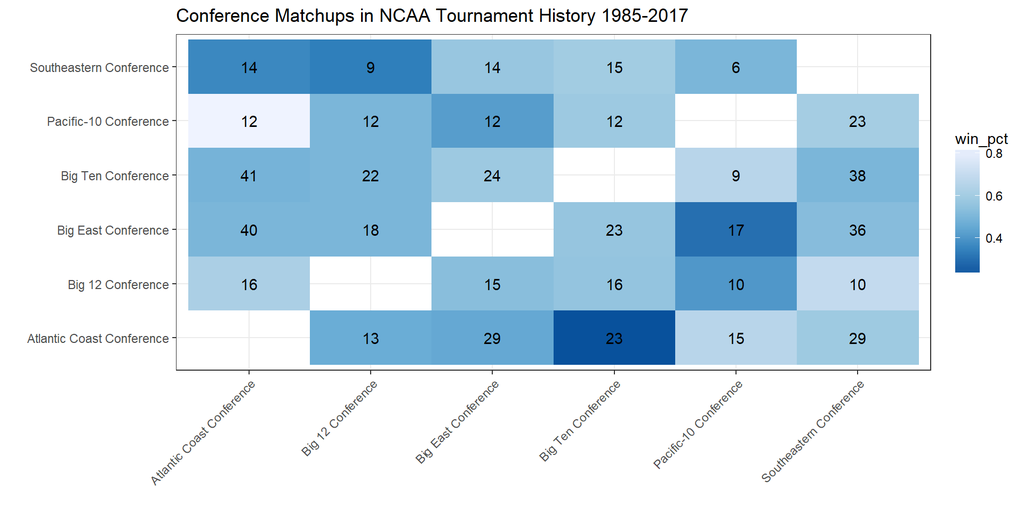

```r
top_conf <- c('acc', 'big_east', 'sec', 'big_ten', 'pac_ten', 'big_twelve')

tour_results[, .(Season,
TeamID1 = pmin(WTeamID, LTeamID),
TeamID2 = pmax(WTeamID, LTeamID),
low_team_win = ifelse(WTeamID == pmin(WTeamID, LTeamID), 1, 0))
][team_conferences, on = c(TeamID1 = 'TeamID', 'Season'), nomatch = 0
][team_conferences, on = c(TeamID2 = 'TeamID', 'Season'), nomatch = 0
][ConfAbbrev %in% top_conf & i.ConfAbbrev %in% top_conf
][, .(win_pct = sum(low_team_win) / .N, n = .N), by = c('ConfAbbrev', 'i.ConfAbbrev')
][conferences, on = 'ConfAbbrev',  nomatch = 0
][conferences, on = c(i.ConfAbbrev = 'ConfAbbrev'), nomatch = 0
][ConfAbbrev != i.ConfAbbrev] %>%
ggplot(aes(x = Description, y = i.Description, fill = win_pct)) +
geom_tile() +
geom_text(aes(label = n)) +
theme(axis.text.x = element_text(angle = 45, hjust = 1)) +
labs(x = '', y = '', title = 'Conference Matchups in NCAA Tournament History 1985-2017') +
scale_fill_distiller(palette = "Blues")
```

# Here, the fill color represents the percentage of times that a team from the conference on the x-axis beat a team from the conference on the y-axis. The number in the center of each tile shows how many times such a matchup occured. For example we see that when Big Ten Conference team played an Atlantic Coast Conference team 23 times and that the Big Ten Conference team only won a small percentage of the games.

## Indicators of Regular Season Success

# Let’s now turn to the regular season game statistics. We are interested in knowing how certain statistics correlate with winning vs losing. We will take the regular season detail and first convert it to a more ‘long’ format with only 1 column of TeamIDs and a factor indicating whether that row corresponds to a win or a loss. Here I also add some additional game statistcs. These include field goal percentage, free throw percentage, offensive/defensive rebounding efficiency, and possessions. These last two come from Laksan Nathan’s kernel [here](https://www.kaggle.com/lnatml/feature-engineering-with-advanced-stats).

```r
win_stats <- seas_detail[, .(
Season,
TeamID = WTeamID,
Outcome = rep('W', .N),
FGM = WFGM,
FGA = WFGA,
FGP = WFGM / WFGA,
FGP2 = (WFGM - WFGM3) / (WFGA - WFGA3),
FGM3 = WFGM3,
FGA3 = WFGA3,
FGP3 = WFGM3 / WFGA3,
FTM = WFTM,
FTA = WFTA,
FTP = WFTM / WFTA,
OR = WOR,
DR = WDR,
AST = WAst,
TO = WTO,
STL = WStl,
BLK = WBlk,
PF = WPF,
ORP = WOR / (WOR + LDR),
DRP = WDR / (WDR + LOR),
POS = 0.96 * (WFGA + WTO + 0.44 * WFTA - WOR)
)]

los_stats <- seas_detail[, .(
Season,
TeamID = LTeamID,
Outcome = rep('L', .N),
FGM = LFGM,
FGA = LFGA,
FGP = LFGM / LFGA,
FGP2 = (LFGM - LFGM3) / (LFGA - LFGA3),
FGM3 = LFGM3,
FGA3 = LFGA3,
FGP3 = LFGM3 / LFGA3,
FTM = LFTM,
FTA = LFTA,
FTP = LFTM / LFTA,
OR = LOR,
DR = LDR,
AST = LAst,
TO = LTO,
STL = LStl,
BLK = LBlk,
PF = LPF,
ORP = (LOR / (LOR + WDR)),
DRP = LDR / (LDR + WOR),
POS = 0.96 * (LFGA + LTO + 0.44 * LFTA - LOR)
)]

stats_all <- rbindlist(list(win_stats, los_stats))
```

# Now let’s take a look at the distributions of these statistics for winning and losing teams.

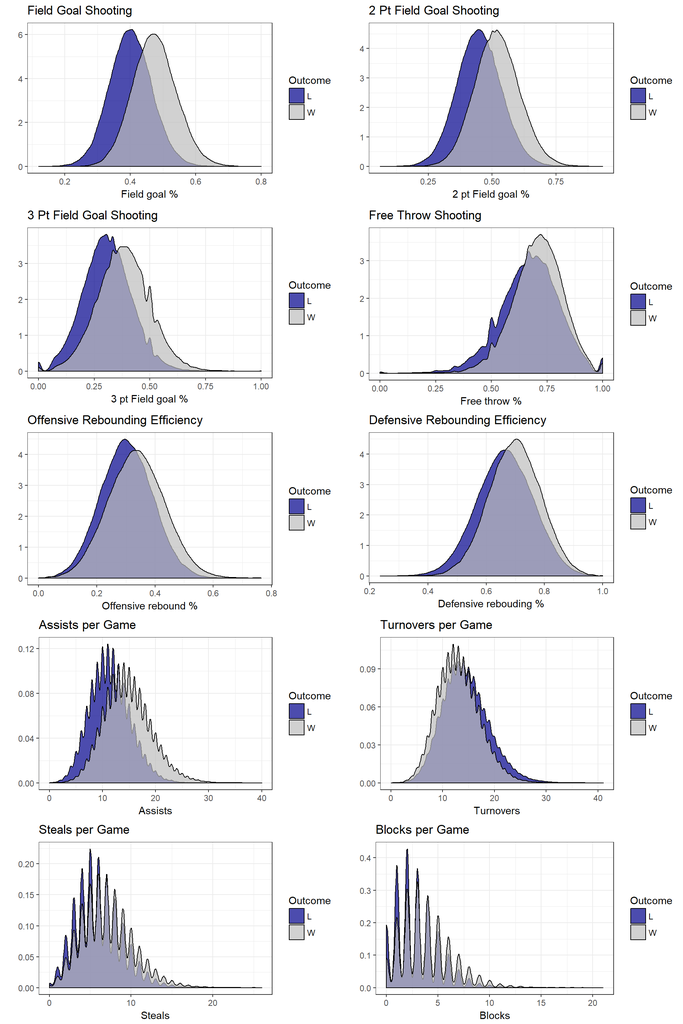

```r
g1 <- stats_all %>%
  ggplot(aes(x = FGP, fill = Outcome)) +
  geom_density(alpha = 0.7) +
  scale_fill_manual(values = c('darkblue', 'grey')) +
  labs(x = 'Field goal %', y = '', title = 'Field Goal Shooting')

g2 <- stats_all %>%
  ggplot(aes(x = FGP2, fill = Outcome)) +
  geom_density(alpha = 0.7) +
  scale_fill_manual(values = c('darkblue', 'grey')) +
  labs(x = '2 pt Field goal %', y = '', title = '2 Pt Field Goal Shooting')

g3 <- stats_all %>%
  ggplot(aes(x = FGP3, fill = Outcome)) +
  geom_density(alpha = 0.7) +
  scale_fill_manual(values = c('darkblue', 'grey')) +
  labs(x = '3 pt Field goal %', y = '', title = '3 Pt Field Goal Shooting')

g4 <- stats_all %>%
  ggplot(aes(x = FTP, fill = Outcome)) +
  geom_density(alpha = 0.7) +
  scale_fill_manual(values = c('darkblue', 'grey')) +
  labs(x = 'Free throw %', y = '', title = 'Free Throw Shooting')

g5 <- stats_all %>%
  ggplot(aes(x = ORP, fill = Outcome)) +
  geom_density(alpha = 0.7) +
  scale_fill_manual(values = c('darkblue', 'grey')) +
  labs(x = 'Offensive rebound %', y = '', title = 'Offensive Rebounding Efficiency')

g6 <- stats_all %>%
  ggplot(aes(x = DRP, fill = Outcome)) +
  geom_density(alpha = 0.7) +
  scale_fill_manual(values = c('darkblue', 'grey')) +
  labs(x = 'Defensive rebouding %', y = '', title = 'Defensive Rebounding Efficiency')

g7 <- stats_all %>%
  ggplot(aes(x = AST, fill = Outcome)) +
  geom_density(alpha = 0.7) +
  scale_fill_manual(values = c('darkblue', 'grey')) +
  labs(x = 'Assists', y = '', title = 'Assists per Game')

g8 <- stats_all %>%
  ggplot(aes(x = TO, fill = Outcome)) +
  geom_density(alpha = 0.7) +
  scale_fill_manual(values = c('darkblue', 'grey')) +
  labs(x = 'Turnovers', y = '', title = 'Turnovers per Game')

g9 <- stats_all %>%
  ggplot(aes(x = STL, fill = Outcome)) +
  geom_density(alpha = 0.7) +
  scale_fill_manual(values = c('darkblue', 'grey')) +
  labs(x = 'Steals', y = '', title = 'Steals per Game')

g10 <- stats_all %>%
  ggplot(aes(x = BLK, fill = Outcome)) +
  geom_density(alpha = 0.7) +
  scale_fill_manual(values = c('darkblue', 'grey')) +
  labs(x = 'Blocks', y = '', title = 'Blocks per Game')

grid.arrange(g1, g2, g3, g4, g5, g6, g7, g8, g9, g10, ncol = 2)
```

# Unsurprisingly, we see that winning teams tend to have a higher mean (or lower in the case of turnover) in pretty much every metric. The last few plots are bit spikey due to the more discrete nature of the data.

# We don’t have final game statistics until we have the game result, so we obviously can’t use these statistics in this form to predict the winners of tournament matchups. However, we can use regular season aggregate statistics to predict the winner in tournament matchups. Let’s take a look at that next.

## Predictors of Tournament Success

# One of the obvious predictors for how deep a team goes in the tournament would be regular season wins. Let’s see how regular season wins correlate to tournament progress each year.

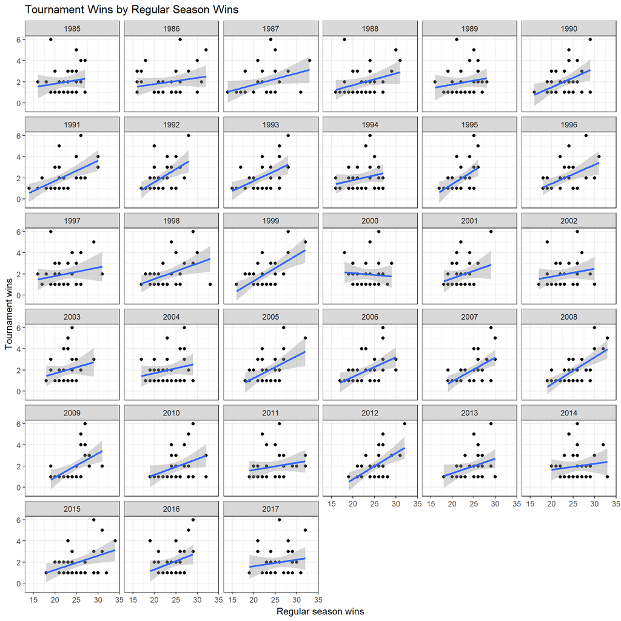

```r
wins_s <- seas_results[, .(rsW = .N), by = c('WTeamID', 'Season')]

wins_t <- tour_results[!(DayNum %in% c(134, 135)), .(tW = .N), by = c('WTeamID', 'Season')]


wins_teams <- wins_s[wins_t][teams]

wins_teams[!is.na(Season), ] %>%
  ggplot(aes(x = rsW, y = tW)) +
  geom_point() +
  geom_smooth(method = 'lm') +
  facet_wrap( ~ as.factor(Season)) +
  labs(
    x = 'Regular season wins',
    y = 'Tournament wins',
    title = 'Tournament Wins by Regular Season Wins')
```

# In nearly every year, tournament wins is positively correlated with regular season wins. Of course, there are some exceptions - for example in 2000, the relationship is slightly negative! Single-elimination tournaments produce some variations as they leave little room for error. Sometimes strong favorites don’t get as far as expected.